# Sparse Kronecker PCA

Can Hakan Dagidir

2022-05-19

## Data:

- 6 months training 2019 Jan to Jun
- 6 months test 2020 Jan to Jun
- 5 of the datasets have 3x3 locations, the other one (aliaga) has 2x2 locations

## Sparse Kronecker PCA in Depth Analysis

### Figure 1

Here we see the change in train and test errors as we change the number of principal components in Sparse Kronecker PCA.

The numbers on the plot represent the number of PCs at the lowest test error.

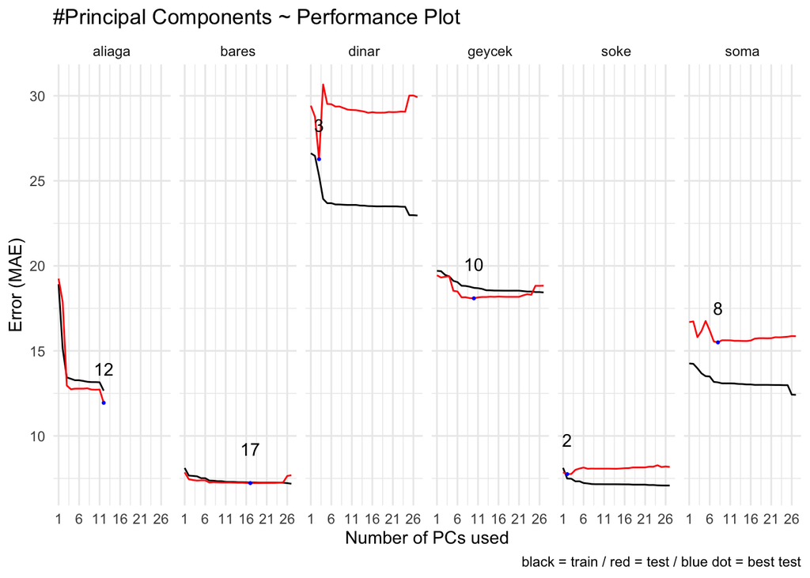

### Figure 2

Here we see the change in explained variance with number of principal components.

Blue and Purple lines represent 99%th and 99.9%th explained varience.

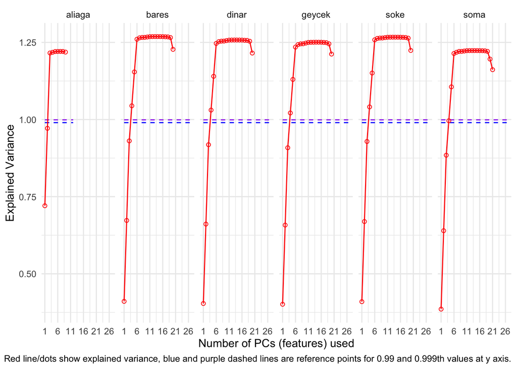

### Close Look

#### Aliaga

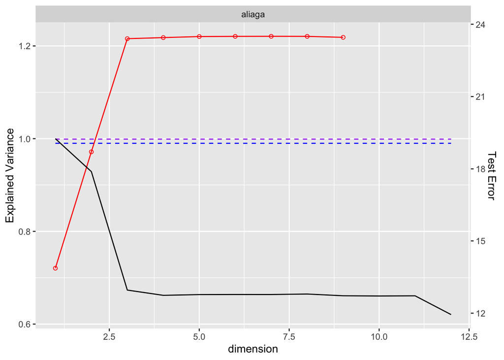

#### Bares

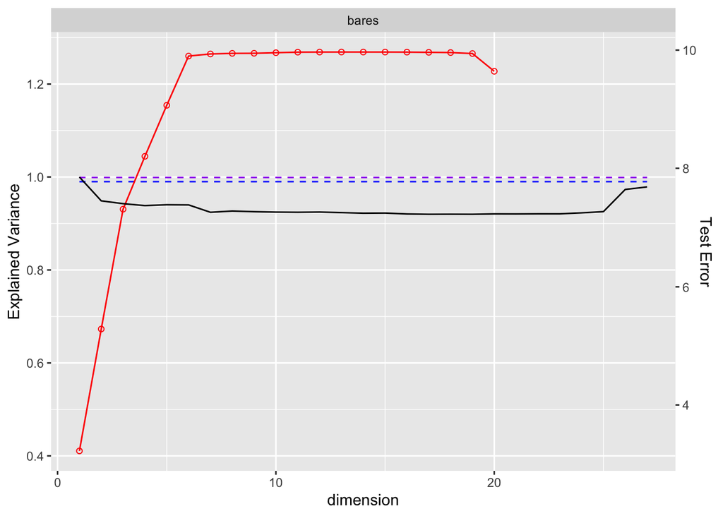

#### Dinar

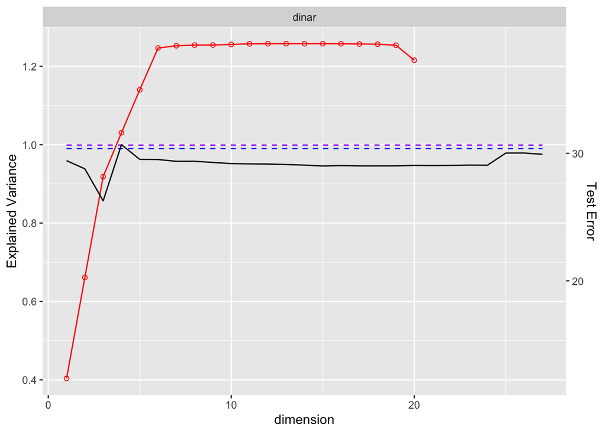

#### Geycek

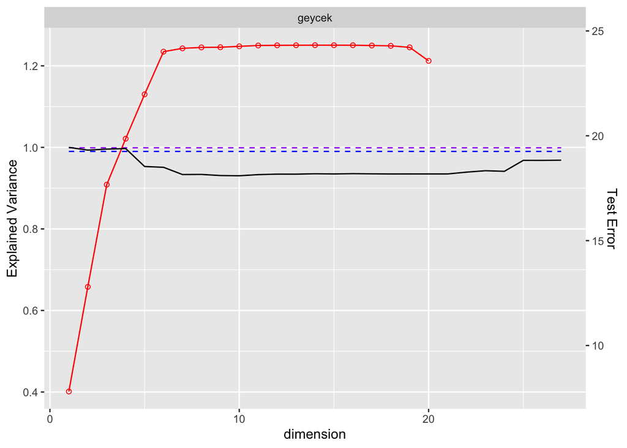

#### Soke

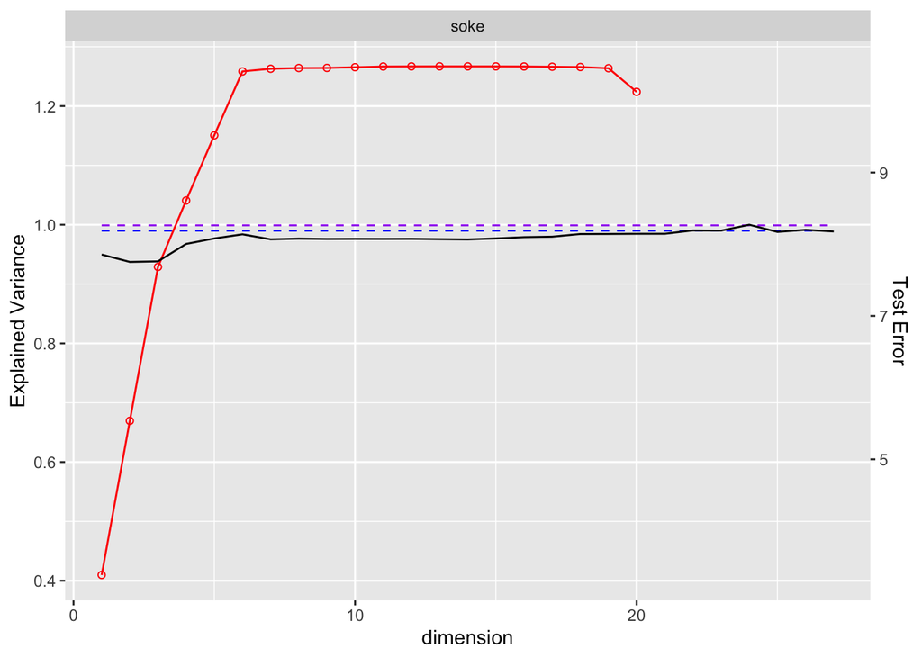

#### Soma

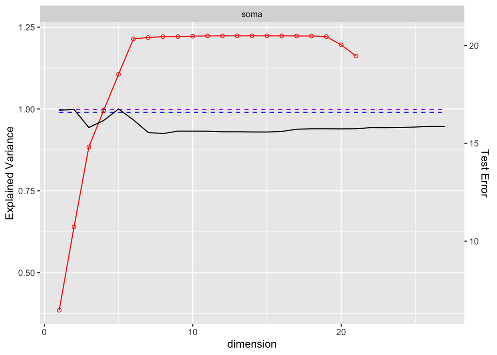

## Sparse Kronecker PCA on POWER in Depth Analysis

### Figure 1

Here we see the change in train and test errors as we change the number of principal components in Sparse Kronecker PCA.

The numbers on the plot represent the number of PCs at the lowest test error.

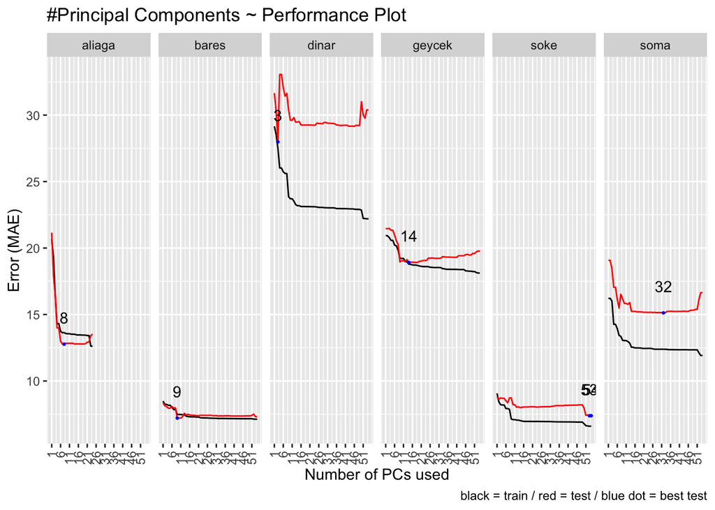

### Figure 2

Here we see the change in explained variance with number of principal components.

Blue and Purple lines represent 99%th and 99.9%th explained varience.

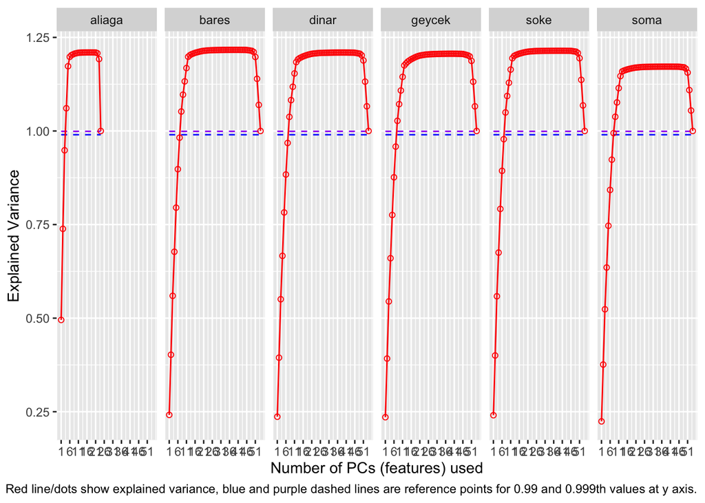

### Close Look

#### Aliaga

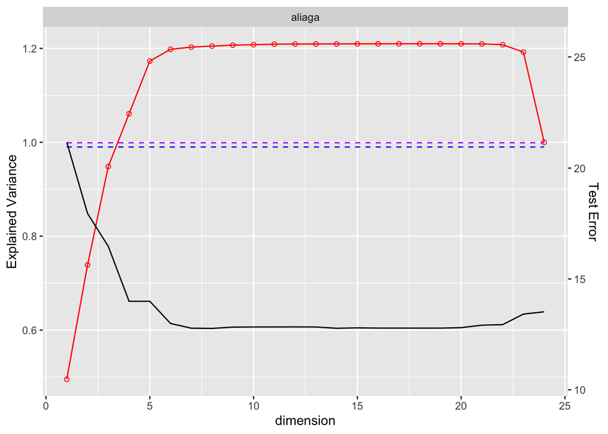

#### Bares

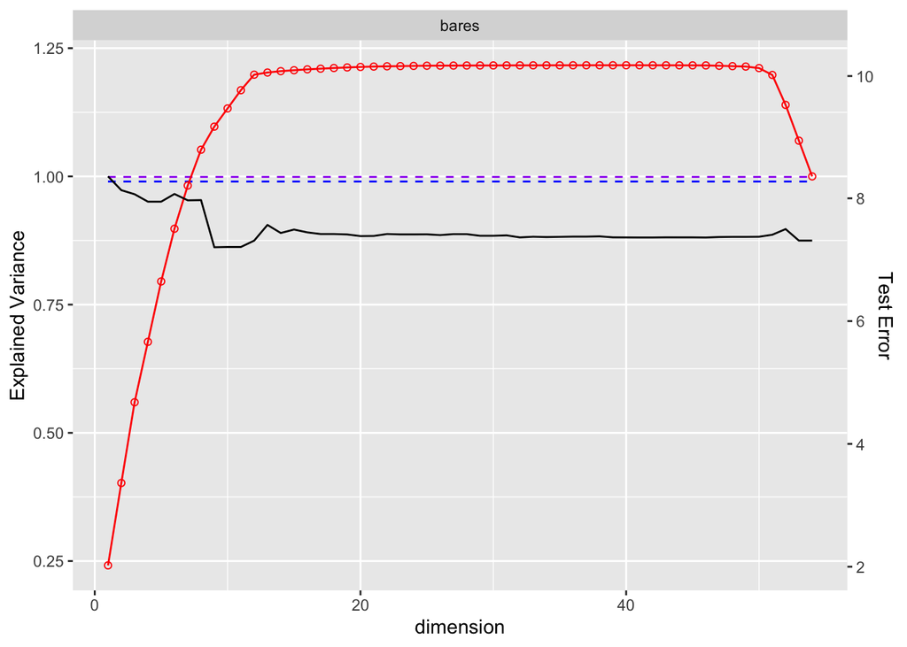

#### Dinar

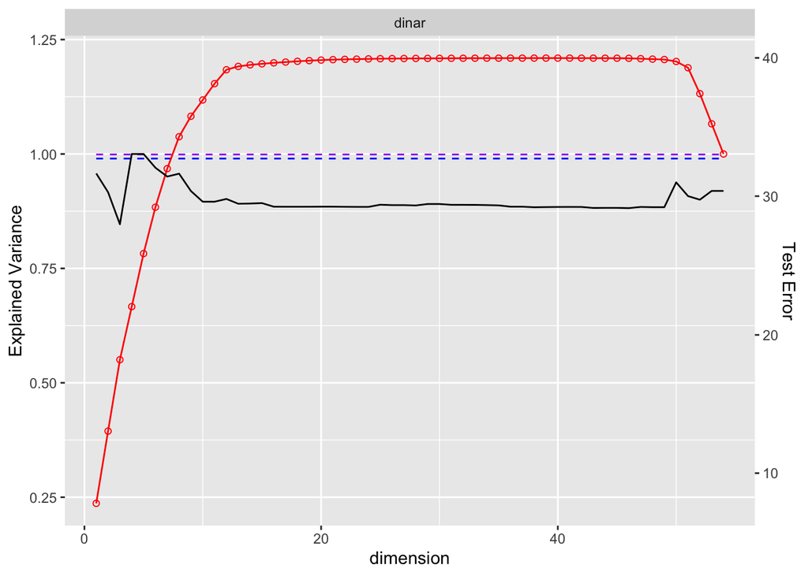

#### Geycek

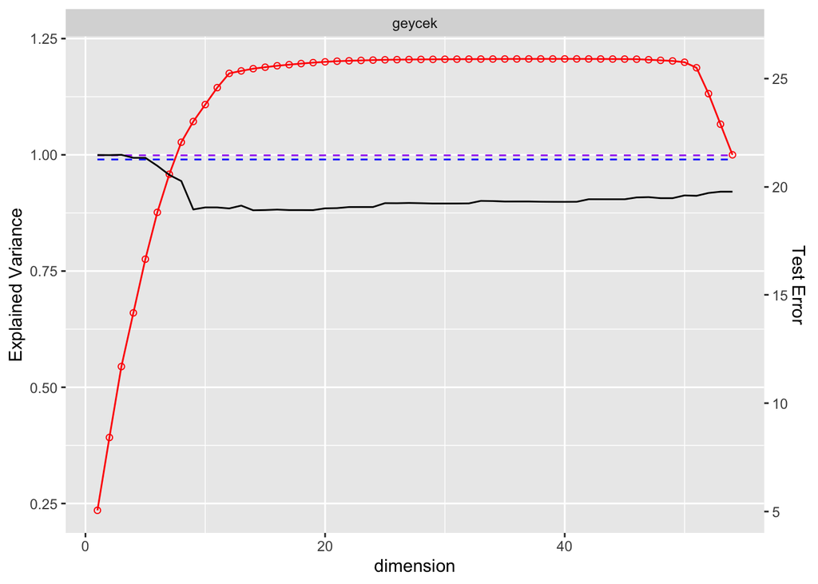

#### Soke

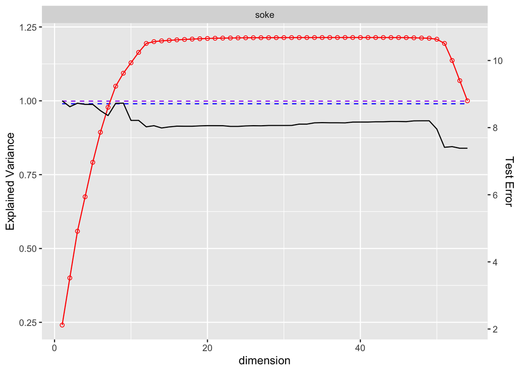

#### Soma

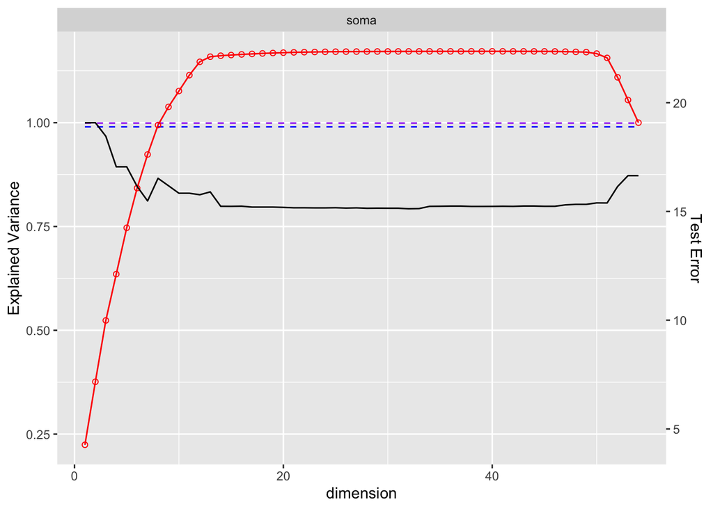